# Assignment - Week 03

Yara Roth

2026-03-09

# Code

## Setup

```r
suppressPackageStartupMessages({
  library(AnnotationHub)
  library(Rsubread)
  library(rtracklayer)
  library(Biostrings)
  library(Rfastp)
  library(epiwraps)
})
ah <- AnnotationHub()

library(rstudioapi)
setwd(dirname(rstudioapi::getActiveDocumentContext()$path))
```

## Download ChiP-seq for CTCF protein

```r
dir.create("data")
dir.create("data/raw")
download.file("https://www.encodeproject.org/files/ENCFF127RRR/@@download/ENCFF127RRR.fastq.gz", "data/raw/ctcf_input.fastq.gz", timeout = 5000)
```

## Quality Control and Trimming

### Quality Control

Now we will perform quality control, to look at the quality of the reads. I did perform this directly in my terminal.

```bash
mkdir -p data/raw_fastqc
fastqc -o data/raw_fastqc --threads 4 data/raw/*.fastq.gz
```

The html file with the results can be found in `week03/data/raw_fastqc/`.  
The quality of the reads is not optimal, we have a mean quality score of ~23, with increasing variability towards the end of the reads. No adapter sequences were identified.

### Trimming

```r
dir.create("data/rfastp.trimmed")
qc <- Rfastp::rfastp(
  read1="data/raw/ctcf_input.fastq.gz",
  thread=4,
  overrepresentationAnalysis=TRUE,
  adapterTrimming = TRUE,
  outputFastq="data/rfastp.trimmed/ctcf_trimmed"
)
```

Reads get trimmed if mean quality drops below 20 for a bp window of 4 or if an adapter gets detected. 98.26% passed the filtering, meaning they had sufficient quality (less than 40% bases below Q15) and had a goon N content.

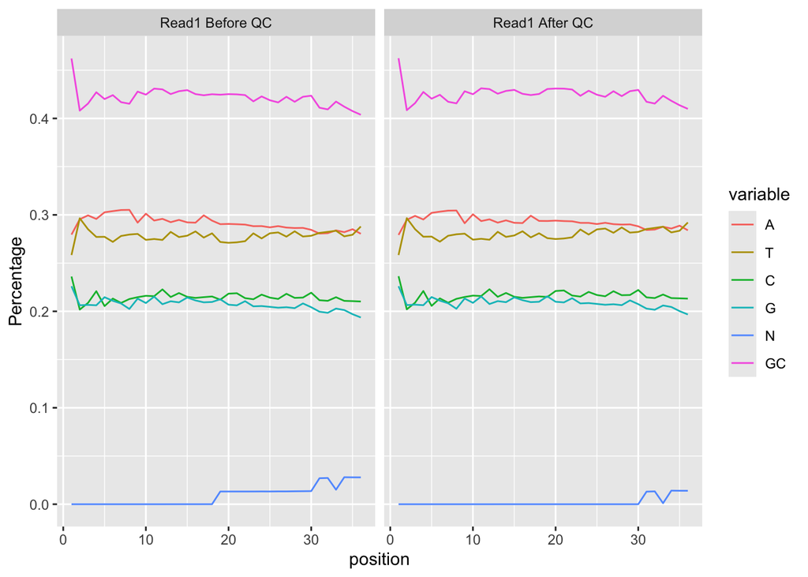

```r
Rfastp::curvePlot(qc, curve="content_curves")
```

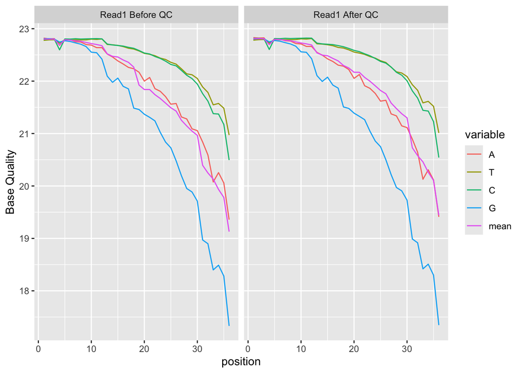

```r
Rfastp::curvePlot(qc, curve="quality_curves")
```

## Alignment

Now we want to get the genome sequence for the drosophila melangaster in a TwoBit format for BDGP6 (we already downloaded it last week). We will use the latest available genome.

### Retrieving drosophila genome

```r
query_results <- query(ah, c("Drosophila melanogaster","TwoBitFile","dna_sm","BDGP6"))

mcols(query_results)[, c("title", "rdatadateadded")]
```

```
## DataFrame with 24 rows and 2 columns
##                           title rdatadateadded
##                     <character>    <character>
## AH49674  Drosophila_melanogas..     2015-12-28
## AH50019  Drosophila_melanogas..     2015-12-29
## AH50510  Drosophila_melanogas..     2016-05-03
## AH51198  Drosophila_melanogas..     2016-08-15
## AH51544  Drosophila_melanogas..     2016-11-03
## ...                         ...            ...
## AH90691  Drosophila_melanogas..     2020-10-27
## AH92960  Drosophila_melanogas..     2021-05-17
## AH99424  Drosophila_melanogas..     2021-10-20
## AH103729 Drosophila_melanogas..     2022-04-21
## AH106160 Drosophila_melanogas..     2022-04-25
```

```r
query_results[length(query_results)]
```

```
## AnnotationHub with 1 record
## # snapshotDate(): 2025-10-29
## # names(): AH106160
## # $dataprovider: Ensembl
## # $species: drosophila melanogaster
## # $rdataclass: TwoBitFile
## # $rdatadateadded: 2022-04-25
## # $title: Drosophila_melanogaster.BDGP6.32.dna_sm.toplevel.2bit
## # $description: TwoBit DNA sequence for drosophila melanogaster
## # $taxonomyid: 7227
## # $genome: BDGP6.32
## # $sourcetype: FASTA
## # $sourceurl: ftp://ftp.ensembl.org/pub/release-107/fasta/drosophila_melanog...
## # $sourcesize: NA
## # $tags: c("TwoBit", "ensembl", "sequence", "2bit", "FASTA")
## # retrieve record with 'object[["AH106160"]]'
```

```r
genome_d <- ah[["AH106160"]]
```

```
## loading from cache
```

```r
dir.create("data/BDGP6_genome")
export(import.2bit(genome_d), "data/BDGP6_genome/genome.fasta.gz", compress=TRUE)
```

### Building Genome Index

Now we will build the genome index based on our BDGP6 genome, which will allow us to map/align the reads.

```r
if (!file.exists("data/BDGP6_genome/rsubread.files")) {
  Rsubread::buildindex("data/BDGP6_genome/rsubread", reference="data/BDGP6_genome/genome.fasta.gz")
} else {
  message("Index already built.")
}
```

```
## Index already built.
```

### Alignment

Now we will perform the mapping.

```r
dir.create("data/aligned")
align.stats <- Rsubread::align(
  index="data/BDGP6_genome/rsubread",
  type="dna",
  readfile1="data/rfastp.trimmed/ctcf_trimmed_R1.fastq.gz",output_file="data/aligned/ctcf.bam",
  nthreads=6,
  sortReadsByCoordinates=TRUE
)
```

[output not shown]

[output cut: 26 more lines]

```
##
## //================================   Summary =================================\\
## ||                                                                            ||
## ||                 Total reads : 3,816,990                                    ||
## ||                      Mapped : 3,505,377 (91.8%)                            ||
## ||             Uniquely mapped : 3,048,961                                    ||
## ||               Multi-mapping : 456,416                                      ||
## ||                                                                            ||
## ||                    Unmapped : 311,613                                      ||
## ||                                                                            ||
## ||                      Indels : 1,835                                        ||
## ||                                                                            ||
## ||                Running time : 4.4 minutes                                  ||
## ||                                                                            ||
## \\============================================================================//
```

```r
align.stats
```

```
##                       ctcf.bam
## Total_reads            3816990
## Mapped_reads           3505377
## Uniquely_mapped_reads  3048961
## Multi_mapping_reads     456416
## Unmapped_reads          311613
## Indels                    1835
```

We have a mappability of 91.8% which is very high. The bam file can be found in `data/aligned/ctcf.bam`.

## Peak calling

```r
BiocManager::install("MACSr")
library(MACSr)
```

Now we will extract the peaks and their supplementary information (location) using:

```r
dir.create("data/peaks")
callpeak(
  tfile="data/aligned/ctcf.bam",
  gsize="dm",
  outdir = "data/peaks",
  name = "ctcf"
)
```

[output not shown]

```
## macsList class
## $outputs:
##  data/peaks/ctcf_model.r
##  data/peaks/ctcf_peaks.narrowPeak
##  data/peaks/ctcf_peaks.xls
##  data/peaks/ctcf_summits.bed
## $arguments: tfile, gsize, outdir, name
## $log:
##  INFO  @ 12 Mar 2026 12:25:38: [2875 MB]
##  # Command line:
##  # ARGUMENTS LIST:
##  # name = ctcf
##  # format = AUTO
## ...
```

```r
peaks <- rtracklayer::import("data/peaks/ctcf_peaks.narrowPeak", format="narrowPeak")
peaks
```

```
## GRanges object with 5405 ranges and 6 metadata columns:
##                 seqnames      ranges strand |           name     score
##                    <Rle>   <IRanges>  <Rle> |    <character> <numeric>
##      [1] 211000022278132     155-471      * |    ctcf_peak_1        80
##      [2] 211000022278137       1-396      * |    ctcf_peak_2       687
##      [3] 211000022278151       1-313      * |    ctcf_peak_3       203
##      [4] 211000022278152     349-664      * |    ctcf_peak_4        56
##      [5] 211000022278158    726-1036      * |    ctcf_peak_5       473
##      ...             ...         ...    ... .            ...       ...
##   [5401]            rDNA 70330-70518      * | ctcf_peak_5401        85
##   [5402]            rDNA 72426-72620      * | ctcf_peak_5402        98
##   [5403]            rDNA 72725-73074      * | ctcf_peak_5403       141
##   [5404]            rDNA 73636-73966      * | ctcf_peak_5404       110
##   [5405]            rDNA 74235-74565      * | ctcf_peak_5405       153
##          signalValue    pValue    qValue      peak
##            <numeric> <numeric> <numeric> <integer>
##      [1]     5.12413  10.32560   8.03410       172
##      [2]    18.44690  71.70410  68.76970       213
##      [3]     8.45482  22.88640  20.34790       170
##      [4]     4.35551   7.86764   5.66918       160
##      [5]    14.34760  50.16970  47.37110       140
##      ...         ...       ...       ...       ...
##   [5401]     3.37885   10.8619   8.55657        24
##   [5402]     3.57941   12.1502   9.80677       170
##   [5403]     4.19698   16.6319  14.19240       173
##   [5404]     3.81929   13.3810  11.00840       163
##   [5405]     4.48699   17.8504  15.38710       161
##   -------
##   seqinfo: 298 sequences from an unspecified genome; no seqlengths
```

# Report

## Number of identified peaks

A total of 5405 peaks were identified for the protein CTCF.

## Peak Signal inside a gene

To identify peaks that lie within a gene, we first need to extract the genes from the drosophila EnsDb.

```r
query_results <- query(ah, c("Drosophila","EnsDb","BDGP6"))
query_results[length(query_results)]
```

```
## AnnotationHub with 1 record
## # snapshotDate(): 2025-10-29
## # names(): AH119285
## # $dataprovider: Ensembl
## # $species: Drosophila melanogaster
## # $rdataclass: EnsDb
## # $rdatadateadded: 2024-10-28
## # $title: Ensembl 113 EnsDb for Drosophila melanogaster
## # $description: Gene and protein annotations for Drosophila melanogaster bas...
## # $taxonomyid: 7227
## # $genome: BDGP6.46
## # $sourcetype: ensembl
## # $sourceurl: http://www.ensembl.org
## # $sourcesize: NA
## # $tags: c("113", "Annotation", "AnnotationHubSoftware", "Coverage",
## #   "DataImport", "EnsDb", "Ensembl", "Gene", "Protein", "Sequencing",
## #   "Transcript")
## # retrieve record with 'object[["AH119285"]]'
```

```r
ensdb_d <- ah[["AH119285"]]
```

```
## loading from cache
```

```
## require("ensembldb")
```

```r
genes_d <- genes(ensdb_d)
head(genes_d)
```

```
## GRanges object with 6 ranges and 9 metadata columns:
##                                       seqnames      ranges strand |
##                                          <Rle>   <IRanges>  <Rle> |
##                    FBgn0267594 211000022278279 11634-12709      - |
##                    FBgn0259849 211000022278436   1551-2815      - |
##                    FBgn0085494 211000022278449    528-1635      - |
##                    FBgn0085506 211000022278760     562-879      - |
##   RR41606_transposable_element 211000022278978    515-2242      + |
##   RR51478_transposable_element 211000022278978   2243-3964      + |
##                                               gene_id       gene_name
##                                           <character>     <character>
##                    FBgn0267594            FBgn0267594         CR45932
##                    FBgn0259849            FBgn0259849 Su(Ste):CR42418
##                    FBgn0085494            FBgn0085494    Mst77Y-16Psi
##                    FBgn0085506            FBgn0085506         CG40635
##   RR41606_transposable_element RR41606_transposable..  Bari1{}RR41606
##   RR51478_transposable_element RR51478_transposable..  Bari1{}RR51478
##                                        gene_biotype seq_coord_system
##                                         <character>      <character>
##                    FBgn0267594           pseudogene primary_assembly
##                    FBgn0259849                ncRNA primary_assembly
##                    FBgn0085494           pseudogene primary_assembly
##                    FBgn0085506       protein_coding primary_assembly
##   RR41606_transposable_element transposable_element primary_assembly
##   RR51478_transposable_element transposable_element primary_assembly
##                                           description        gene_id_version
##                                           <character>            <character>
##                    FBgn0267594                   NULL            FBgn0267594
##                    FBgn0259849        Su(Ste):CR42418            FBgn0259849
##                    FBgn0085494 Male-specific pseudo..            FBgn0085494
##                    FBgn0085506                   NULL            FBgn0085506
##   RR41606_transposable_element                   NULL RR41606_transposable..
##   RR51478_transposable_element                   NULL RR51478_transposable..
##                                  canonical_transcript          symbol entrezid
##                                           <character>     <character>   <list>
##                    FBgn0267594            FBtr0347033         CR45932     <NA>
##                    FBgn0259849            FBtr0300146 Su(Ste):CR42418  7354452
##                    FBgn0085494            FBtr0308947    Mst77Y-16Psi  5740181
##                    FBgn0085506            FBtr0302344         CG40635  5740827
##   RR41606_transposable_element RR41606_transposable..  Bari1{}RR41606     <NA>
##   RR51478_transposable_element RR51478_transposable..  Bari1{}RR51478     <NA>
##   -------
##   seqinfo: 29 sequences (1 circular) from BDGP6.46 genome
```

When I tried to extract the peaks that lie within a gene, I got a warning that I have a mismatch between the naming conventions of peaks and genes_d. I tried to solve it with the following chunk. Unfortunately, I still received a warning after and did not manage to resolve the issue completely. Maybe we could look at that in the lecture.

```r
seqlevelsStyle(peaks) <- seqlevelsStyle(genes_d)
```

```
## Warning in .normarg_seqlevelsStyle(value): more than one seqlevels style
## supplied, using the 1st one only
```

```r
peaks_in_genes <- suppressWarnings(peaks[overlapsAny(peaks, genes_d, type="within")])
peaks_in_genes
```

```
## GRanges object with 1908 ranges and 6 metadata columns:
##                 seqnames        ranges strand |           name     score
##                    <Rle>     <IRanges>  <Rle> |    <character> <numeric>
##      [1] 211000022279188     1494-1811      * |  ctcf_peak_178       124
##      [2]              2L   35482-35813      * |  ctcf_peak_410       574
##      [3]              2L   42056-42317      * |  ctcf_peak_411        97
##      [4]              2L   73106-73463      * |  ctcf_peak_413       331
##      [5]              2L 107756-108001      * |  ctcf_peak_416        84
##      ...             ...           ...    ... .            ...       ...
##   [1904]            rDNA   70330-70518      * | ctcf_peak_5401        85
##   [1905]            rDNA   72426-72620      * | ctcf_peak_5402        98
##   [1906]            rDNA   72725-73074      * | ctcf_peak_5403       141
##   [1907]            rDNA   73636-73966      * | ctcf_peak_5404       110
##   [1908]            rDNA   74235-74565      * | ctcf_peak_5405       153
##          signalValue    pValue    qValue      peak
##            <numeric> <numeric> <numeric> <integer>
##      [1]     6.40517   14.8287  12.42290       156
##      [2]    12.92030   60.3273  57.45980       161
##      [3]     5.30973   12.1389   9.79578       110
##      [4]     9.44493   35.8298  33.14920       130
##      [5]     4.67290   10.7131   8.41174       137
##      ...         ...       ...       ...       ...
##   [1904]     3.37885   10.8619   8.55657        24
##   [1905]     3.57941   12.1502   9.80677       170
##   [1906]     4.19698   16.6319  14.19240       173
##   [1907]     3.81929   13.3810  11.00840       163
##   [1908]     4.48699   17.8504  15.38710       161
##   -------
##   seqinfo: 298 sequences from an unspecified genome; no seqlengths
```

Now i will select the biggest peak we have (so the one with the highest score).

```r
biggest_peak_idx <- which.max(peaks_in_genes$score)
biggest_peak <- peaks_in_genes[biggest_peak_idx]
```

Next I’ll extraxt the name of the gene, in which the peak is located.

```r
gene_idx <- suppressWarnings(subjectHits(findOverlaps(biggest_peak, genes_d)))
gene_name <- genes_d[gene_idx]$gene_name
gene_name
```

```
## [1] "Svil"
```

And lastly we can plot everything:

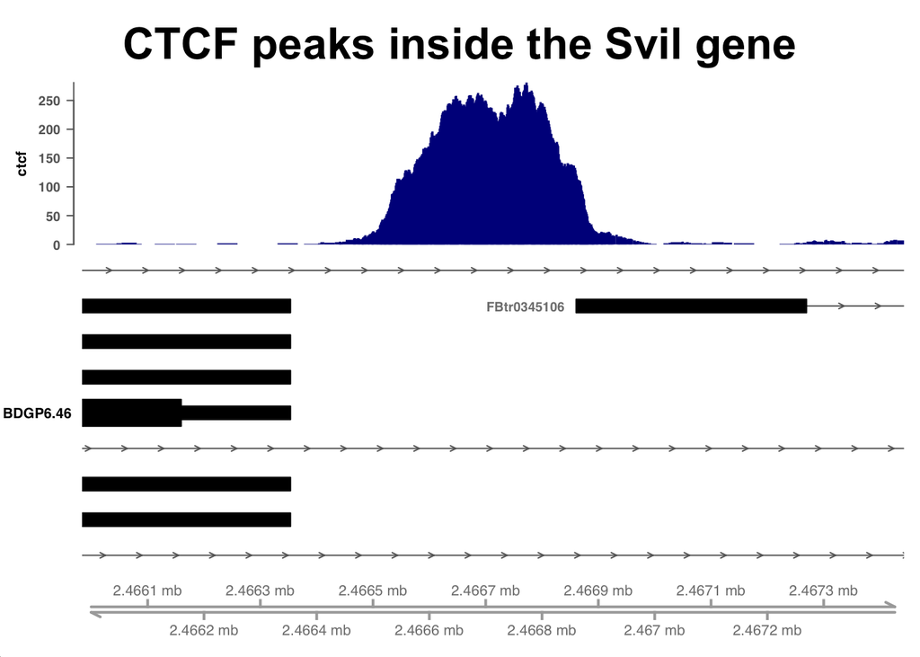

```r
plotSignalTracks(
  list(ctcf = "data/aligned/ctcf.bam"),
  region = biggest_peak,
  extend = 500,
  genomeAxis = TRUE,
  ensdb = ensdb_d,
  transcripts = "full",
  main = paste("CTCF peaks inside the", gene_name, "gene")
)
```